# DATA 211 Final Project

Brandon Conrady

4/19/2022

```r
library(tidyverse)
```

```r
library(ggplot2)
library(readxl)
TransactionData <- read_xlsx('C:\\Users\\Brandon\\Downloads\\Transactions.xlsx')
```

# Welcome to my final project.

# I am a cashier at Home Depot.

# I want to see if there is a difference in the transactions made at Self Checkouts (SCO) and regular registers (Mainline).

# I will be looking at some figures I collected to test this.

# The dataset is called “TransactionData”, and contains 817 entries.

# Listed are the date of the transaction, day of week, register, SCO_Flag, and total for transaction.

# SCO_Flag denotes “SCO” for SCO, and “Mainline” for all other transactions

```r
summary(TransactionData)
```

```
##       Date                      DayOfWeek           Register
##  Min.   :2022-03-27 00:00:00   Length:817         Length:817
##  1st Qu.:2022-04-02 00:00:00   Class :character   Class :character
##  Median :2022-04-03 00:00:00   Mode  :character   Mode  :character
##  Mean   :2022-04-05 05:41:56
##  3rd Qu.:2022-04-08 00:00:00
##  Max.   :2022-04-18 00:00:00
##    SCO_Flag             Total
##  Length:817         Min.   :   0.35
##  Class :character   1st Qu.:  20.08
##  Mode  :character   Median :  44.99
##                     Mean   :  86.33
##                     3rd Qu.:  93.39
##                     Max.   :1989.82
```

# To get the full picture of the data we’re working with, lets view the number of entries sorted by Register and SCO_Flag.

```r
TransactionData %>%
  group_by(Register) %>%
  summarize(count = n())
```

| Register | count |
| --- | --- |
| 1 | 141 |
| 2 | 69 |
| 3 | 4 |
| Garden | 10 |
| SCO | 593 |

```r
TransactionData %>%
  group_by(SCO_Flag) %>%
  summarize(count = n())
```

| SCO_Flag | count |
| --- | --- |
| Mainline | 224 |
| SCO | 593 |

# As we can see, there are almost triple the number of SCO transactions than all other types combined.

# Next I will view the ranges of Total values sorted by Register and SCO_Flag.

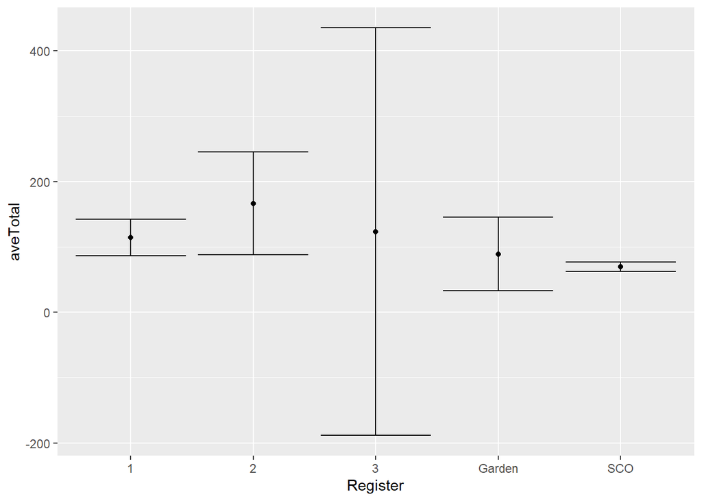

```r
TransactionData %>%
  group_by(Register) %>%
  summarize(aveTotal = mean(Total), seTotal = sd(Total)/sqrt(length(Total)), tstar = qt(1-0.05/2, length(Total) - 1)) %>%
  ggplot(aes(x = Register, y = aveTotal)) + geom_point() + geom_errorbar(aes(ymin = aveTotal - seTotal*tstar, ymax = aveTotal + seTotal*tstar))
```

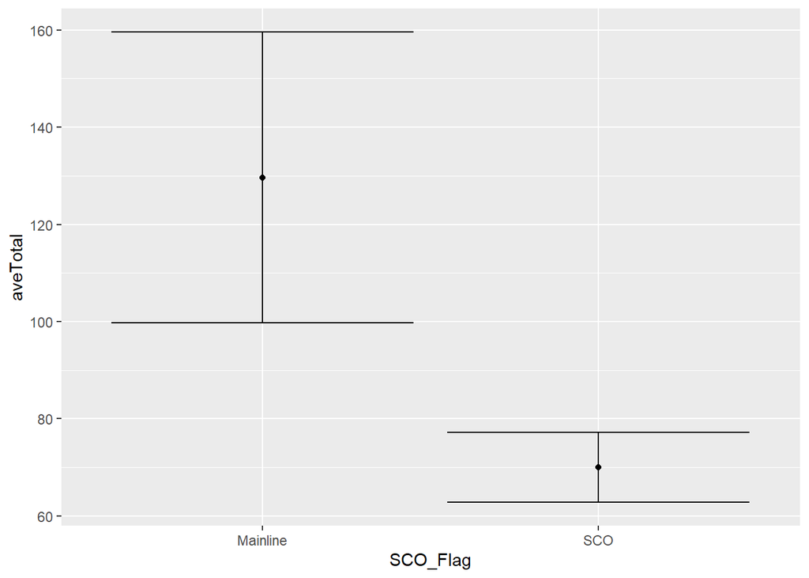

```r
TransactionData %>%
  group_by(SCO_Flag) %>%
  summarize(aveTotal = mean(Total), seTotal = sd(Total)/sqrt(length(Total)), tstar = qt(1-0.05/2, length(Total) - 1)) %>%
  ggplot(aes(x = SCO_Flag, y = aveTotal)) + geom_point() + geom_errorbar(aes(ymin = aveTotal - seTotal*tstar, ymax = aveTotal + seTotal*tstar))
```

# As a consequence of having so many SCO entries, we can see its confidence interval is much smaller than the other types.

# Based on the graph alone, we can see that there is indeed a signifiant difference between SCO and Mainline transactions.

# However, to be safe, we will perform a t-test anyways to verify that.

# The question I will attempt to answer: “Is the amount spent at a Self Checkout significantly less than the amount spent at a regular register by customers on average?”

# Null hypothesis: mu(Mainline) = mu(SCO)

# Alternative hypothesis: mu(Mainline) > mu(SCO)

```r
t.test(Total~SCO_Flag, data = TransactionData, alternative = "greater")
```

```
##
##  Welch Two Sample t-test
##
## data:  Total by SCO_Flag
## t = 3.8179, df = 249.27, p-value = 8.493e-05
## alternative hypothesis: true difference in means is greater than 0
## 95 percent confidence interval:
##  33.85542      Inf
## sample estimates:
## mean in group Mainline      mean in group SCO
##              129.62558               69.97585
```

# Based on the low p-value, we can reject the null hypothesis.

# Furthermore, we can safely say there is evidence to back the claim that SCO transactions are significantly lower than Mainline transactions on average.